# Why I Stopped Eating Soylent

James Pitt

September 15, 2018

Is eating Soylent 1.5 for every meal more dangerous than eating normal foods, in terms of lead and cadmium exposure? This is an analysis I ran a few years ago to answer that question for myself. I’ve refactored a couple bits that were unreadable (mostly by adding Tidyverse), but this remains a pretty simple analysis.

# Background:

You’ve probably heard of Soylent. A few years back, I was eating a lot of Soylent 1.5. It came out that 1.5 [had lead and cadmium levels above California thresholds.](https://www.eater.com/2015/8/16/9162301/soylent-as-you-sow-cadmium-lead-california)

Now, I knew California has some overly cautious laws, so I initially wasn’t that concerned.

Then I read [Rosa Labs (Soylent’s manufacturer’s) response](https://faq.soylent.com/hc/en-us/articles/204197379-California-Proposition-65) It seemed obvious to me that the meals they cited as a comparison - heavy on fish - were unlikely to be comparable to the metal levels in what people normally eat. So I decided to investigate.

The FDA Total Diet Study provides samples of element levels in all kinds of foods. I decided to aggregate the average lead and cadmium levels in different foods, and compare these averages to the levels Rosa Labs reported in Soylent 1.5.

```r
#Get data
download.file("http://www.fda.gov/downloads/Food/FoodScienceResearch/TotalDietStudy/UCM455198.zip", destfile="./yearstandards.zip")

stds <- read.table(unz("yearstandards.zip", "Elements 2011.txt"), header=TRUE, sep="\t")

#Focus on only the rows containing lead or cadmium
leadandcad <- subset(stds, Element=="CADMIUM" | Element=="LEAD")

#Check whether any entries are in micrograms rather than milligrams
grep("ug/kg", leadandcad$Unit)
```

```
## integer(0)
```

```r
#None are, so don't need to adjust concentrations
```

# Plan

My original analysis plan was to compare a 3-soylent-meal day to 3 “normal” meals constructed from other foods. Use hierarchical clustering to see if 3 Soylent meals 1.5 naturally “falls in the same category” as a lot of other meals, or whether it’s an outlier. Key question is qualitative - whether soylent 3x per day has comparable content to other foods. Whether it’s in the same cluster as a bunch of others, or in a cluster of its own.

I laid out a plan to run the following analyses: -Single meal, lead -Single meal, cad -3 meals mean, lead -3 meals mean, cad -3 meals median, lead -3 meals median, cad and use a Bonferroni correction for multiple comparisons.

I abandoned that analysis plan because it was obvious from the one-meal results that the rest weren’t necessary.

```r
#First, I prep 3 datasets for hierarchical clustering: one for just lead, one for just cadmium, and one for both lead AND cadmium levels.

#Variables I care about: Food.No, Food.Name, Element, Conc
averaged <- aggregate(Conc ~ Food.Name + Element, leadandcad, mean)

#Add a row for Soylent 1.5.
#Manually add in lead/ cad levels from here:
#https://faq.soylent.com/hc/en-us/article_attachments/203065059/prop-65-meals.v2.rev_D.jpg

#Make data frame for Soylent using Rosa Labs concentrations from #https://docs.google.com/spreadsheets/d/1xS8bAQKZoksJfONrEb1N_kFD5Sp-0W-TOJBOJQyLJk8/edit#gid=0

Food.Name <- c("Soylent1.5", "Soylent1.5", "Soylent2.0", "Soylent2.0")
Element <- c("CADMIUM", "LEAD", "CADMIUM", "LEAD")
Conc <- c(0.186, 0.043, 0.010, 0.005)
soyframe <- data.frame(Food.Name, Element, Conc)

averaged <- rbind(averaged, soyframe)

#Split a lead-specific and a cadmium-specific dataset out of the overall data frames.
leadset <- averaged[averaged$Element=="LEAD",]
cadset <- averaged[averaged$Element=="CADMIUM",]

#Simplify these sets into just food name and concentration
simpleleadset <- leadset[,3]
names(simpleleadset) <- leadset$Food.Name

simplecadset <- cadset[,3]
names(simplecadset) <- cadset$Food.Name

#Reshape averaged into having lead conc in one column and cadmium conc in another, and use them as x and y
library(tidyverse)
data_for_hclust <- averaged %>% spread(key=Element, value=Conc)
row.names(data_for_hclust) <- make.names(data_for_hclust[,1])
#Accidentally added names as a column so let's fix that.
data_for_hclust <- data_for_hclust[,-1]
```

Time for clustering!

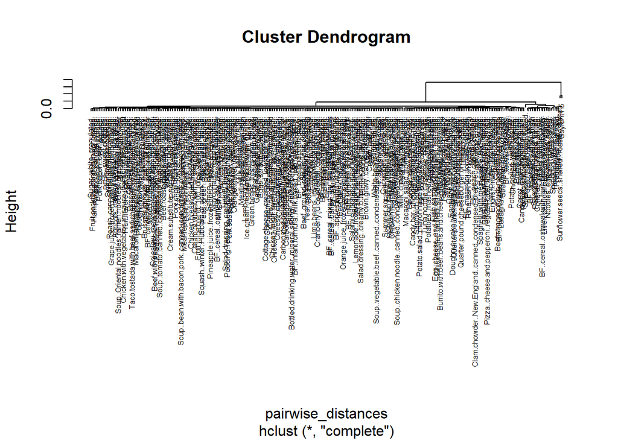

```r
#Now take pairwise distances
pairwise_distances <- dist(data_for_hclust)
hclustering <- hclust(pairwise_distances)
lead_cad_pairwise_distance_clusters <- plot(hclustering, cex=0.5)
```

Holy shit is there an outlier.

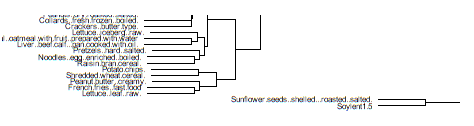

That’s Soylent 1.5 and sunflower seeds. Their mean lead-and-cadmium levels are very different from the levels in other foods.

What about lead alone?

[figure not shown]

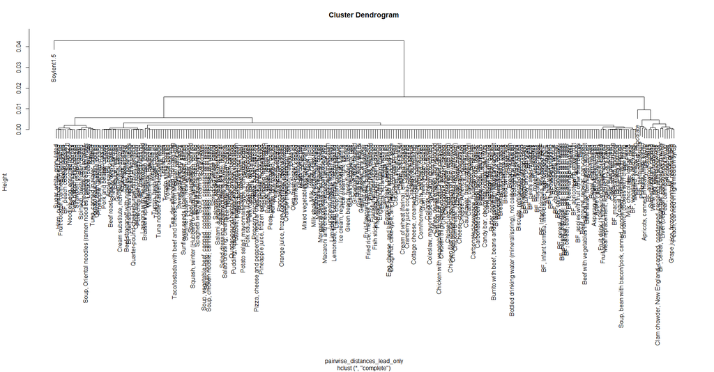

```r
pairwise_distances_lead_only <- dist(simpleleadset)
hclustering_lead_only <- hclust(pairwise_distances_lead_only)
plot(hclustering_lead_only)
```

# WELP

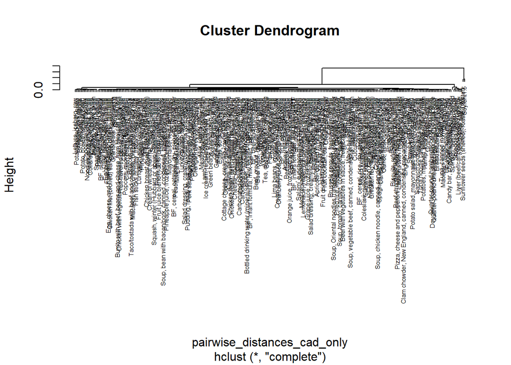

```r
#And cadmium alone?
pairwise_distances_cad_only <- dist(simplecadset)
hclustering_cad_only <- hclust(pairwise_distances_cad_only)
plot(hclustering_cad_only, cex=0.5)
```

Looks the same as the first plot, of lead and cadmium combined. Soylent 1.5 and sunflower seeds are in the same cluster, above every other food.

# Is it worse than the worst case for other foods?

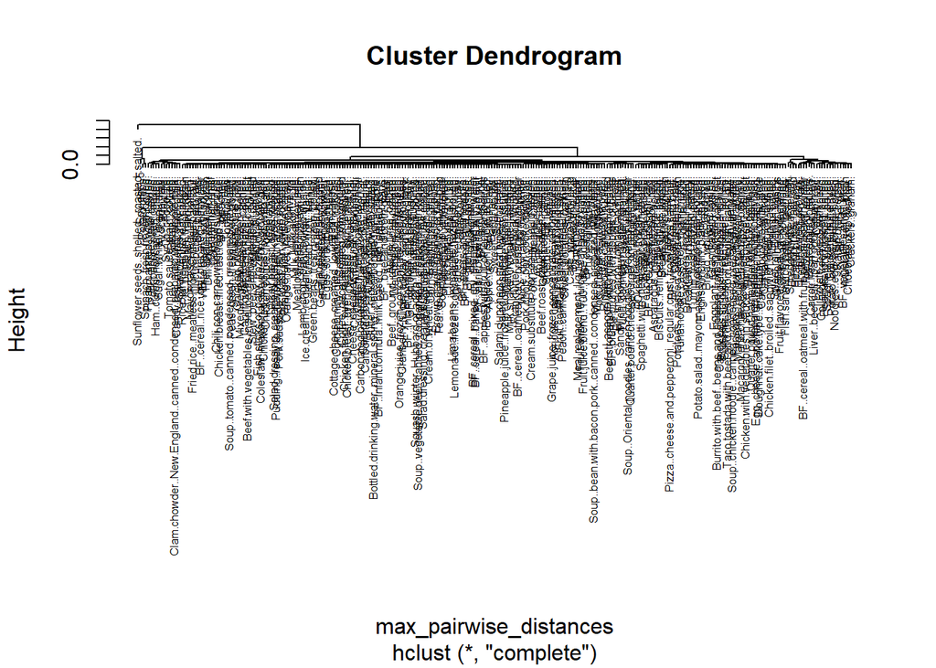

```r
max <- aggregate(Conc ~ Food.Name + Element, leadandcad, FUN=max)
max <- rbind(max, soyframe)

maxleadset <- max[max$Element=="LEAD",]
maxcadset <- max[max$Element=="CADMIUM",]

#Simplify these sets into just food name and concentration
simplemaxleadset <- maxleadset[,3]
names(simplemaxleadset) <- maxleadset$Food.Name

simplemaxcadset <- maxcadset[,3]
names(simplemaxcadset) <- maxcadset$Food.Name

max_data_for_hclust <- max %>% spread(key=Element, value=Conc)
row.names(max_data_for_hclust) <- make.names(max_data_for_hclust[,1])
max_data_for_hclust <- max_data_for_hclust[,-1]

max_pairwise_distances <- dist(max_data_for_hclust)
max_hclustering <- hclust(max_pairwise_distances)
max_lead_cad_pairwise_distance_clusters <- plot(max_hclustering, cex=0.5)
```

Here Soylent 1.5 is no longer in the highest cluster with sunflower seeds… but it’s still an outgroup to everything *except* sunflower seeds

[figure not shown]

```r
pairwise_distances_max_lead_only <- dist(simplemaxleadset)
hclustering_max_lead_only <- hclust(pairwise_distances_max_lead_only)
plot(hclustering_max_lead_only)
```

Still outlier, though closer to things like raw avocado and canned fruit.

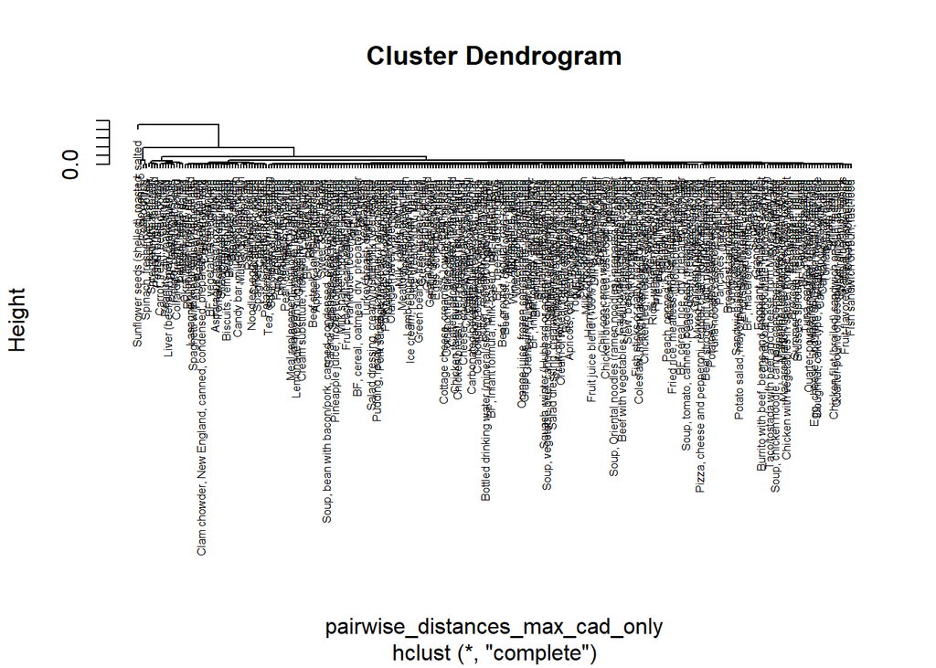

```r
pairwise_distances_max_cad_only <- dist(simplemaxcadset)
hclustering_max_cad_only <- hclust(pairwise_distances_max_cad_only)
plot(hclustering_max_cad_only, cex=0.5)
```

Potato chips and boiled spinach maximums are also bad on cadmium, but Soylent 1.5 is still far from normal.

# Will it hurt me?

Now, I decided three-meal analysis is beside the point. Nothing but an all-sunflower-seed diet would match an all-Soylent-1.5 diet on lead and cadmium levels.

But lots of foods have high-sounding levels of things that are ultimately below the threshold to do harm. *(There’s more recent evidence there’s no lower threshold for lead, but I didn’t know that at the time).* The key question is: will it hurt you?

Find out mass of 3 soylent 1.5 powder meals per day, multiply by concentration, see if it takes you over the daily limit.

```r
#files.soylent.com/pdf/soylent-nutrition-facts.pdf
#115 grams per serving, 4 servings per pouch.
#460 grams per day -> 0.46 kg

#Cadmium intake per day
0.46*max_data_for_hclust[272,1]
```

```
## [1] 0.08556
```

```r
#That's 0.08556 mg

#Lead:
0.46*max_data_for_hclust[272,2]
```

```
## [1] 0.01978
```

```r
#That's 0.01978 mg

##FDA limits:
#Limits for solid food - lead 6 ppm, liquid food 1 ppm
#Cadmium - 0.1 ppm for "cereals and vegetables"
#The Prop 65 safe harbor level for lead is 0.5 micrograms per day. 60x lower than avg exposure EPA permits in drinking water -> amount they found in Soylent was 1/5 to 1/2 lower than what EPA permits in drinking water

#mg/kg converts 1:1 to ppm, as you can see through dimensional analysis.
```

The cadmium level is higher than the FDA cereals-and-vegetables limit, and if liquid makes it more bioavailable that is a real problem. That scared me more than the lead.

That’s why I stopped eating Soylent 1.5. I never tried 2.0 because I found the powder more convenient than keeping bottles of liquid around - and also the early on stories of people finding mold in 2.0. I’ve since gotten into cooking rather than trying to live on meal replacements, but if you have a trustworthy sort-of-food feel free to tell me about it.